# IA-SVA based feature selection improves the performance of clustering algorithms [2]

Donghyung Lee

2017-04-11

The IA-SVA based feature selection can improve the performance of clustering algorithms (e.g., tSNE or hierarchical clustering). To illustrate how the IA-SVA method can be used to improve the performance of clustering algorithms, we use real-world single cell RNA sequencing (scRNA-Seq) data obtained from human pancreatic islet samples ([Lawlor et. al., 2016](http://genome.cshlp.org/content/early/2017/01/16/gr.212720.116)). This dataset is included in a R data package (“iasvaExamples”) containing data examples for IA-SVA (https://github.com/dleelab/iasvaExamples). To install the ‘iasvaExamples’ package, follow the instruction provided in the GitHub page.

## Load packages

```r
rm(list=ls())
library(iasva)
library(iasvaExamples)
library(Rtsne)
library(pheatmap)
library(corrplot)
```

## Load the islet single cell RNA-Seq data

```r
data("Lawlor_Islet_scRNAseq_Read_Counts")
data("Lawlor_Islet_scRNAseq_Annotations")
ls()
```

```
## [1] "Lawlor_Islet_scRNAseq_Annotations" "Lawlor_Islet_scRNAseq_Read_Counts"
```

```r
counts <- Lawlor_Islet_scRNAseq_Read_Counts
anns <- Lawlor_Islet_scRNAseq_Annotations
dim(anns)
```

```
## [1] 638  26
```

```r
dim(counts)
```

```
## [1] 26616   638
```

```r
# set seed for the random number generator.
set.seed(344532456)
```

The annotations describing the islet samples and experimental settings are stored in “anns” and the read counts information is stored in “counts”.

## Filter out low-expressed genes

```r
counts <- counts[, (anns$Cell_Type!="none")]
anns <- subset(anns, (Cell_Type!="none"))
dim(counts)
```

[1] 26616 617

```r
dim(anns)
```

[1] 617 26

```r
anns <- droplevels(anns)

prop.zeros <- sum(counts==0)/length(counts)
prop.zeros
```

[1] 0.6867034

```r
filter = apply(counts, 1, function(x) length(x[x>5])>=3)

counts = counts[filter,]
dim(counts)
```

[1] 18131 617

```r
prop.zeros <- sum(counts==0)/length(counts)
prop.zeros
```

[1] 0.5422856

```r
Patient_ID <- anns$Patient_ID
Cell_Type <- anns$Cell_Type
Phenotype <- anns$Phenotype
Batch <- anns$Batch
```

## Calculate geometric library size, i.e., library size of log-transfromed read counts

It is well known that the geometric library size (i.e., library size of log-transfromed read counts) or proportion of expressed genes in each cell explains very large portion of variability of scRNA-Seq data ([Hicks et. al. 2015 BioRxiv](http://biorxiv.org/content/early/2015/08/25/025528), [McDavid et. al. 2016 Nature Biotechnology](http://www.nature.com/nbt/journal/v34/n6/full/nbt.3498.html)). Frequently, the first principal component of log-transformed scRNA-Seq read counts is highly correlated with the geometric library size. (r > 0.9). Here, we calculate it. Later this vector will be used as an known factor in IA-SVA algorithm.

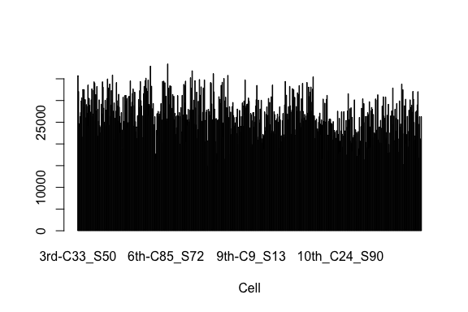

```r
Geo_Lib_Size <- colSums(log(counts+1))
barplot(Geo_Lib_Size, xlab="Cell")
```

```r
lcounts <- log(counts + 1)
pca.res = svd(lcounts - rowMeans(lcounts))$v
cor(Geo_Lib_Size, pca.res[,1])
```

```
## [1] 0.9592539
```

## Run tSNE to cluster islet cells.

For comparison purpose, here we applied tSNE on read counts of all genes. We used the Rtsne R package with default settings.

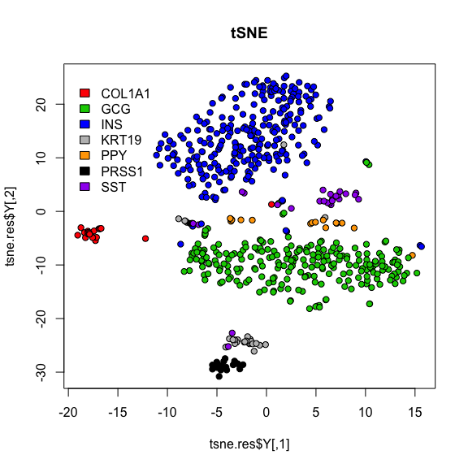

```r
tsne.res <- Rtsne(t(lcounts), dims = 2)

plot(tsne.res$Y, main="tSNE", pch=21, bg=c("red","green3","blue","grey","orange","black","purple")[Cell_Type], oma=c(4,4,6,12))
legend(-20, 25, levels(Cell_Type), fill=c("red", "green3", "blue","grey","orange","black","purple"), bty="n")
```

## Run IA-SVA

Here, we run IA-SVA using Phenotype, Patient_ID, Batch and Geo_Lib_Size as known factors and identify hidden factors.

```r
mod <- model.matrix(~Phenotype+Patient_ID+Batch+Geo_Lib_Size)
iasva.res<- iasva(t(counts), mod[,-1],verbose=FALSE, permute=FALSE, num.sv=10)
```

```
## IA-SVA running...
## SV1 Detected!
## SV2 Detected!
## SV3 Detected!
## SV4 Detected!
## SV5 Detected!
## SV6 Detected!
## SV7 Detected!
## SV8 Detected!
## SV9 Detected!
## SV10 Detected!
## # of significant surrogate variables: 10
```

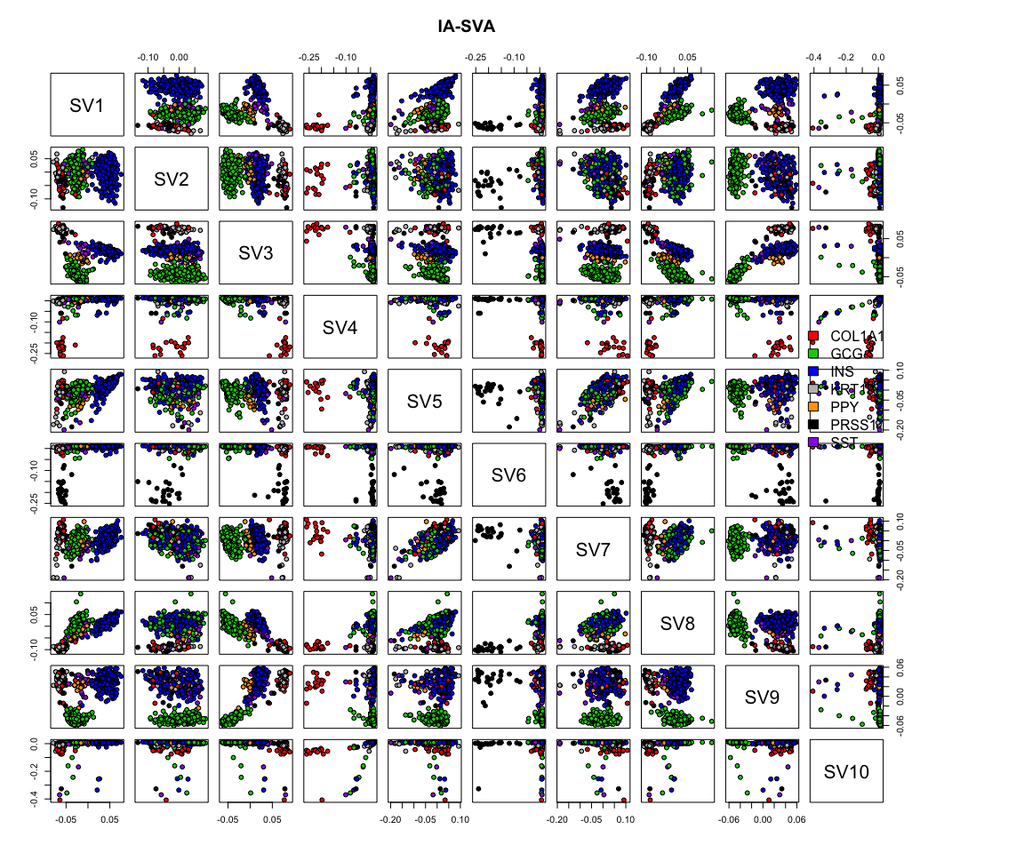

```r
iasva.sv <- iasva.res$sv

pairs(iasva.sv, main="IA-SVA", pch=21, bg=c("red","green3","blue","grey","orange","black","purple")[Cell_Type], oma=c(4,4,6,12))
legend(0.82, 0.65, levels(Cell_Type), fill=c("red", "green3", "blue","grey","orange","black","purple"), bty="n")
```

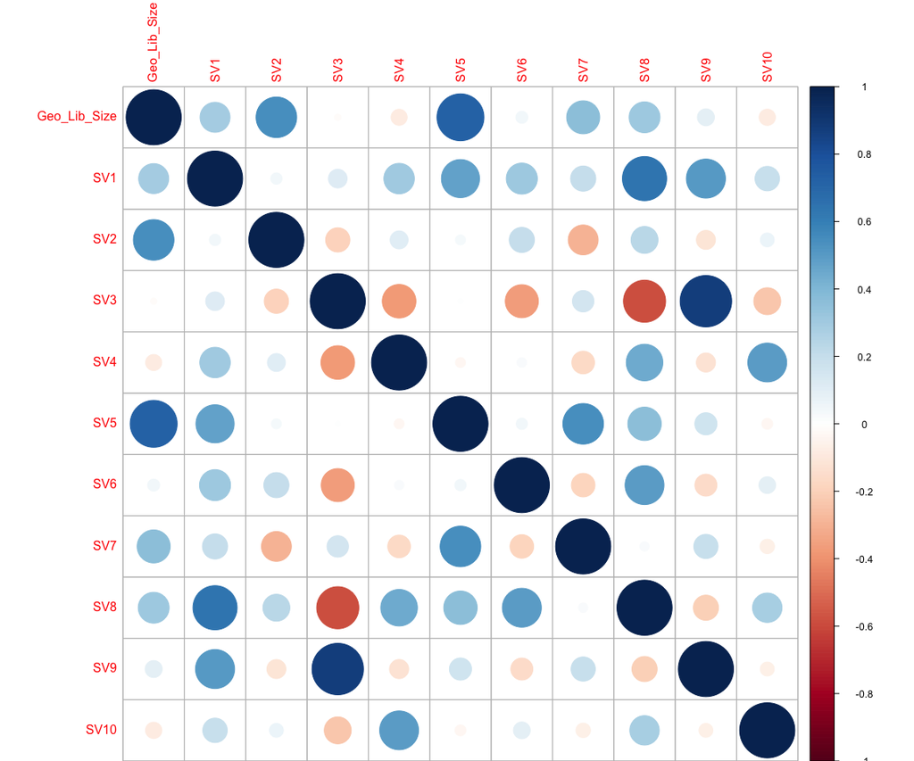

```r
corrplot(cor(cbind(Geo_Lib_Size,iasva.sv)))
```

As shown in the above figure, SV1, SV3, SV4 and SV6 separate cells.

## Find marker genes for SV10.

```r
marker.counts <- find.markers(t(counts), as.matrix(iasva.sv[,c(10)]), sig.cutoff = 0.01, rsq.cutoff = 0.6)
```

```
## # of markers (): 17
## total # of unique markers:  17
```

```r
nrow(marker.counts)
```

```
## [1] 17
```

```r
anno.col <- data.frame(Cell_Type=Cell_Type)
rownames(anno.col) <- colnames(marker.counts)
head(anno.col)
```

```
##             Cell_Type
## 3rd-C33_S50       INS
## 1st-C80_S38       GCG
## 3rd-C32_S31       GCG
## 1st-C51_S41       GCG
## 3rd-C7_S40        GCG
## 1st-C59_S77       GCG
```

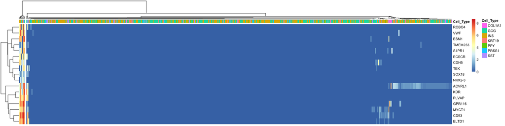

```r
pheatmap(log(marker.counts+1), show_colnames =FALSE, show_rownames = TRUE, clustering_method = "ward.D2",cutree_cols = 2,annotation_col = anno.col)
```

## Find marker genes for SV1, SV3, SV4 and SV6.

Here, we find marker genes significantly associated with SV1, SV3, SV4 and SV6 (multiple testing adjusted p-value < 0.05, default significance cutoff) and having a high R-squared value (R-squared > 0.3) using the find.markers() function.

```r
marker.counts <- find.markers(t(counts), as.matrix(iasva.sv[,c(1,3,4,6)]))
```

```
## # of markers (SV1): 70
## # of markers (SV3): 46
## # of markers (SV4): 160
## # of markers (SV6): 57
## total # of unique markers:  329
```

```r
nrow(marker.counts)
```

[output not shown]

```r
anno.col <- data.frame(Cell_Type=Cell_Type)
rownames(anno.col) <- colnames(marker.counts)
head(anno.col)
```

```
##             Cell_Type
## 3rd-C33_S50       INS
## 1st-C80_S38       GCG
## 3rd-C32_S31       GCG
## 1st-C51_S41       GCG
## 3rd-C7_S40        GCG
## 1st-C59_S77       GCG
```

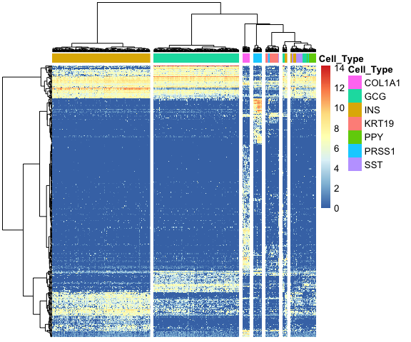

```r
pheatmap(log(marker.counts+1), show_colnames =FALSE, show_rownames = FALSE, clustering_method = "ward.D2",cutree_cols = 7,annotation_col = anno.col)
```

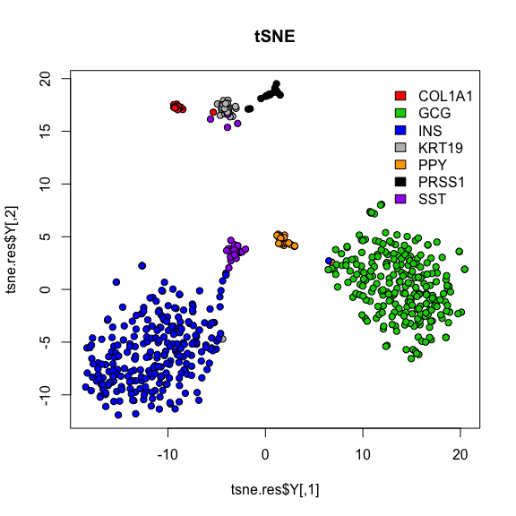

```r
set.seed(75458456)
tsne.res <- Rtsne(unique(t(log(marker.counts+1))), dims = 2)
plot(tsne.res$Y, main="tSNE", pch=21, bg=c("red","green3","blue","grey","orange","black","purple")[Cell_Type], oma=c(4,4,6,12))
legend(12, 20, levels(Cell_Type), fill=c("red", "green3", "blue","grey","orange","black","purple"), bty="n")
```

tSNE post IA-SVA perform better than regular tSNE applied on read counts of entire genes.

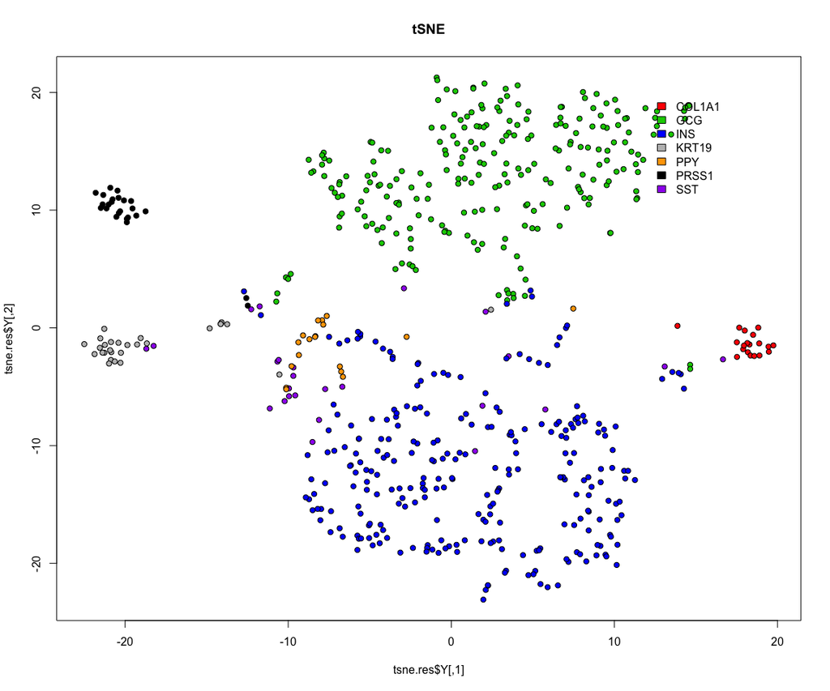

```r
set.seed(3455563)
tsne.res <- Rtsne(pca.res[,c(1:9)], dims = 2)
plot(tsne.res$Y, main="tSNE", pch=21, bg=c("red","green3","blue","grey","orange","black","purple")[Cell_Type], oma=c(4,4,6,12))
legend(12, 20, levels(Cell_Type), fill=c("red", "green3", "blue","grey","orange","black","purple"), bty="n")
```

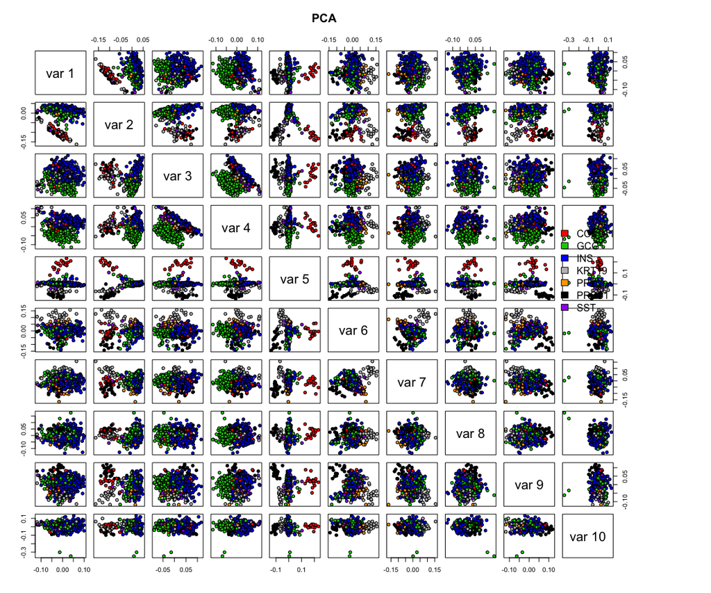

```r
pairs(pca.res[,1:10], main="PCA", pch=21, bg=c("red","green3","blue","grey","orange","black","purple")[Cell_Type], oma=c(4,4,6,12))
legend(0.82, 0.65, levels(Cell_Type), fill=c("red", "green3", "blue","grey","orange","black","purple"), bty="n")
```